# PISA Data 2012

## by Miguel Orellana

## Investigation Overview

This presentation first shows the correlation between the scores obtained by students in each of the 3 disciplines. We see this through a series of 3 scatterplots comparing disciplines two by two.

Afterwards, we can see the relationship between each of the 4 background independent variables and the scores, using the violin and box plots obtained in the exploratory visualization.

## Dataset Overview

PISA is a survey that examines students from compulsory education on how well prepared they are for life after school. This investigation focuses on a selection of variables from the PISA Survey 2012, with data belonging to around 500K students from 65 different countries.

## Correlation between the 3 score variables

The 3 score variables show a linear correlation between each other. This correlation is slightly weaker between math and reading scores, as seen by the more disperse pattern of the scatterplot on the left.

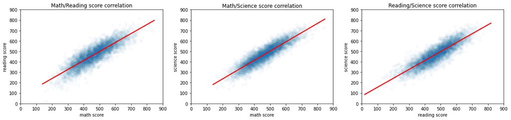

## Score comparison based on student's gender

No clear relationship is appreciated between student's gender and their scores, with the exception of reading, where female students seem to perform better than male students. This can be observed in the upper right box plot of the illustration below.

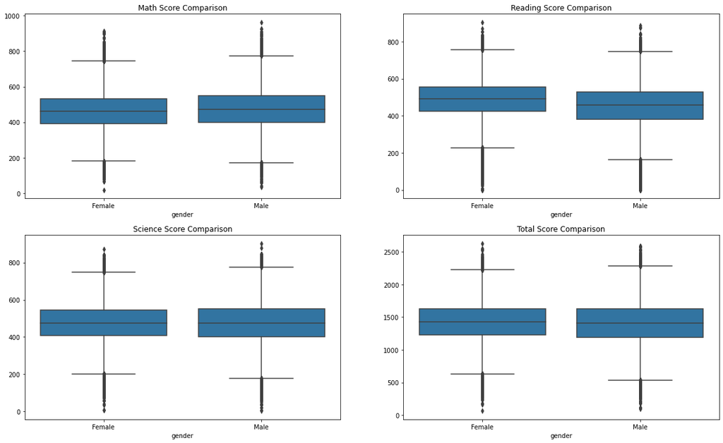

## Score comparison based on OECD membership

Students from OECD countries present better results in the exams across all 3 disciplines. This could indicate that these countries provide a better background for preparing students for the future. In order to know which factors have a greater impact, the PISA survey could be assessed in more detail. Lots of additional variables are provided in the original dataset.

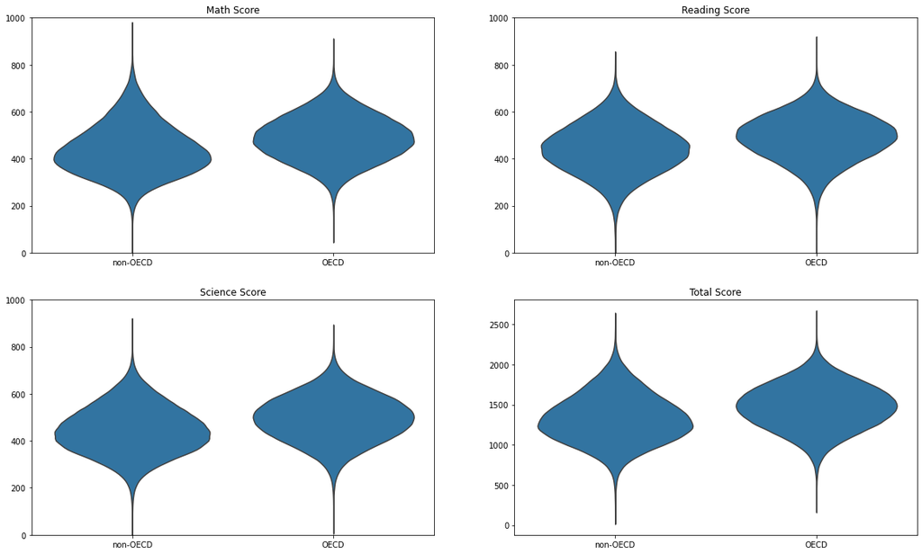

## Score comparison based on parent's education level

Students' whose parents have a higher level of education obtain significantly better scores. The violin plot below shows the score distribution based on the mother's education level. While students whose mother has not completed primary school have a median score of around 1200 points, students whose mother has completed upper secondary school present a median score of around 1500.

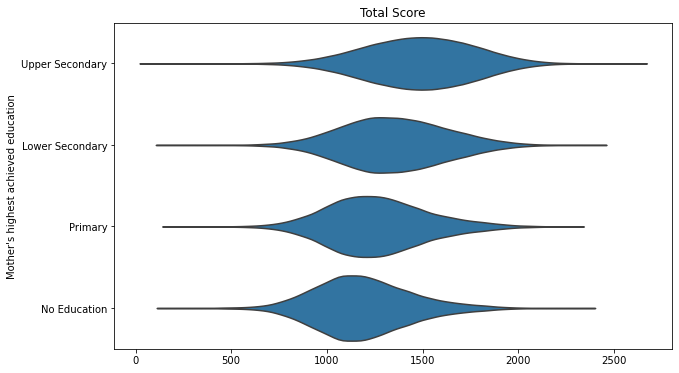

## Score comparison based on internet use at school

[output not shown]